[figure not shown]

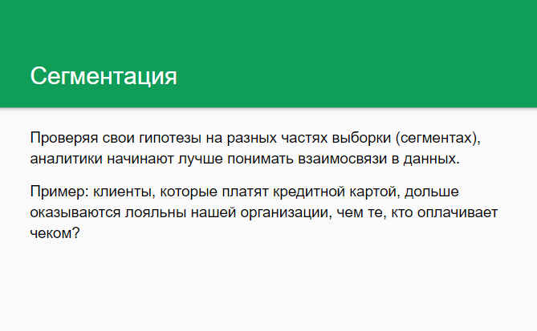

Начнем с того, что загрузим пакеты и данные. Какие данные у нас есть?

```r
library(dplyr)
```

```r
library(readr)
library(ggplot2)
library(magrittr)

customers <- read_csv("~/shared/minor2_2018/1-intro/lab08-segmentation/customers.csv")
dim(customers)
```

```
## [1] 3646   11
```

```r
str(customers, max.level = 1)
```

```
## Classes 'tbl_df', 'tbl' and 'data.frame':    3646 obs. of  11 variables:
##  $ id       : int  1 2 3 5 6 7 8 9 10 11 ...
##  $ Seniority: int  9 17 10 0 1 29 9 0 0 6 ...
##  $ Home     : chr  "rent" "rent" "owner" "rent" ...
##  $ Age      : int  30 58 46 26 36 44 27 32 41 34 ...
##  $ Marital  : chr  "married" "widow" "married" "single" ...
##  $ Records  : chr  "no_rec" "no_rec" "yes_rec" "no_rec" ...
##  $ Job      : chr  "freelance" "fixed" "freelance" "fixed" ...
##  $ Expenses : int  68 52 86 51 60 68 34 78 99 65 ...
##  $ Income   : int  129 131 200 107 214 125 80 107 80 125 ...
##  $ Assets   : int  0 0 3000 0 3500 10000 0 15000 0 4000 ...
##  $ Debt     : int  0 0 0 0 0 0 0 0 0 0 ...
##  - attr(*, "spec")=List of 2
##   ..- attr(*, "class")= chr "col_spec"
```

Есть полезный пакет для описательной статистике по данным – skimr. Он работает долго, поэтому сейчас мы посмотрим сразу на результат функции skim(). А дома вы можете поэксперементировать со своими данными.

```r
library(skimr)
#skim(customers)
```

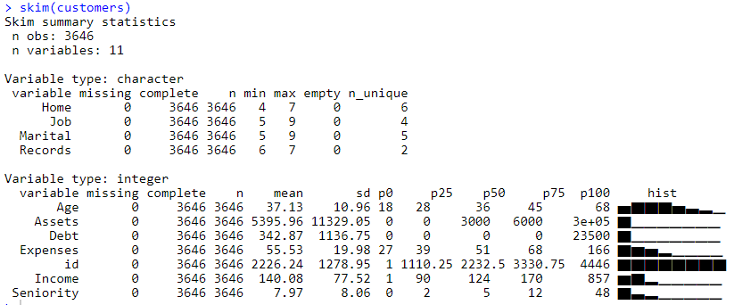

## Наши клиенты – кто они?

Постройте ряд графиков, чтобы ответить на этот вопрос

#### Демографические характеристики клиентов

Как распределен возраст наших клиентов? Нарисуйте гистограмму, посчитайте средний и медианный возраст.

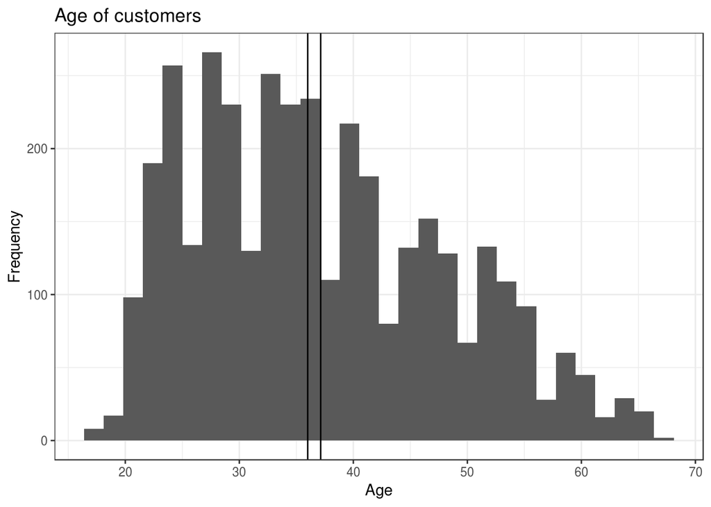

```r
customers %>% ggplot()+
  geom_histogram(aes(Age)) +
  geom_vline(aes(xintercept = mean(Age))) +
  geom_vline(aes(xintercept = median(Age)))+
  xlab("Age")+
  ylab("Frequency")+
  ggtitle("Age of customers")+
  theme_bw()
```

Добавьте на гистограмму заливку по семейному статусу.

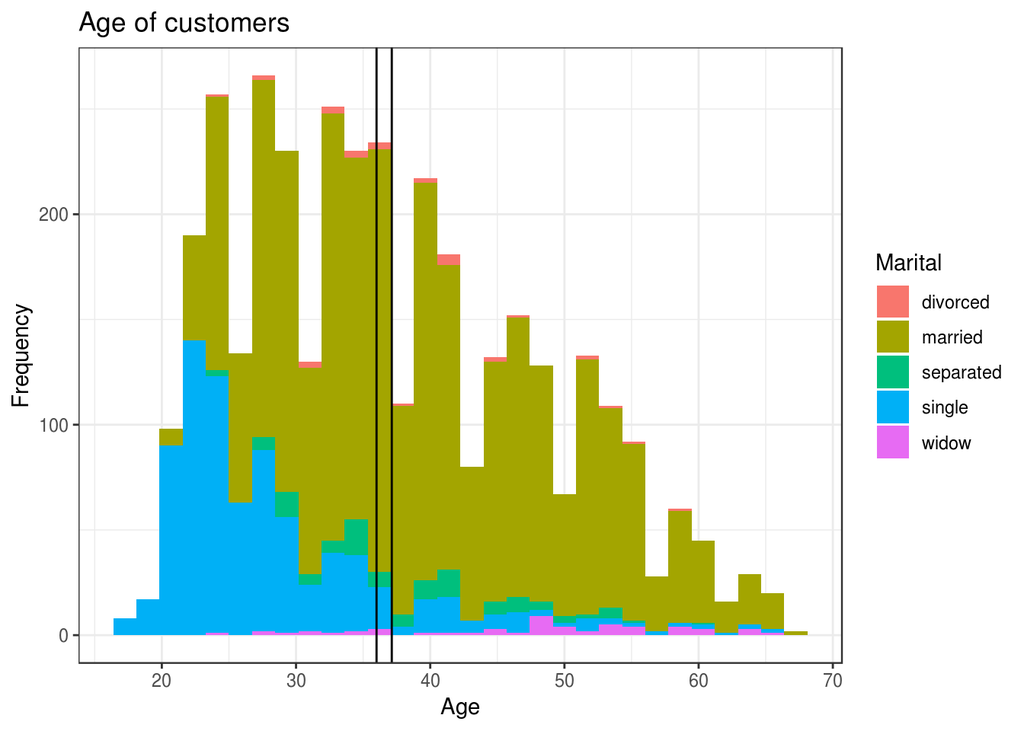

```r
customers %>% ggplot()+
  geom_histogram(aes(Age, fill = Marital)) +
  geom_vline(aes(xintercept = mean(Age))) +
  geom_vline(aes(xintercept = median(Age)))+
  xlab("Age")+
  ylab("Frequency")+
  ggtitle("Age of customers")+
  theme_bw()
```

Сделайте таблицу в которой будет подсчитан средний и медианный возраст клиентов для каждого семейного статуса.

```r
customers %>% group_by(Marital) %>% summarise(mean_age = mean(Age), median_age = median(Age))
```

```
## # A tibble: 5 x 3
##   Marital   mean_age median_age
##   <chr>        <dbl>      <dbl>
## 1 divorced      39.1       38.0
## 2 married       39.5       38.0
## 3 separated     38.3       38.0
## 4 single        28.0       26.0
## 5 widow         48.0       49.0
```

Нарисуйте распределение клиентов по типу владения жильем (переменная Home).

Посчитайте какой процент наших клиентов владеет каждым типом жилья.

Удалите из базы всех клиентов у которых тип жилья ignor, other или priv

#### Зарплата и расходы

Как связана заработная плата и тип занятости? Нарисуйте, который показал бы медианную зарплату по типу занятости и сделайте аналогичню таблицу.

Нарисуйте еще одну гистограмму распределения возраста клиентов. Однако, в этот раз заливкой столбиков отобразите тип занятости. В какой возрастной группе больше всего людей имеют неполную занатость?

Нарисуйте график показывающий связь заработной платы и расходов.

Отличаются ли расходы у людей с разным семейным статусом? Какая категория тратит больше всего?

Высчитайте переменную Savings, отражающую ежегодные сбережения, т.е. количество денег, которые человек ежегодно сохраняет или недосчитывается. Вычите расходы из доходов.

У клиентов с каким семейным статусом и типом занятости медианные сбережения больше всего?

#### Активы и долги

Также в данных есть информация о текущих долгах клиента и его вложених.

Создайте новый датафрейм, в котором будут только записи о тех клиентах, у которых есть долг. В этой части анализировать эту подвыборку.

У клиентов с каким семейным статусом долги больше?

Зависит ли как-то рабочий стаж (Seniority) и текущая задолженность?

### Отчет. Часть 1 – клиентская база

Перенесите наиболее красивые и содержательные картинки и таблицы в файл credit-template.Rmd

## Making new buisness – с чем связана выплата кредита?

На этом этапе мы знаем все о наших клиентах. Предположим, что мы хотим внедрить новый элемент в наш бизнес – мы выдаем кредиты. И хотим все сделать максимально эффективно, то есть прибыльно.

Для пробы мы дали кредит первым нескольким тысячам обратившихся к нам клиентов.

В теперь давайте выясним, как связаны уже известные нам переменные с тем выплатит ли клиент кредит или нет! Сформулируйте гипотезы о связи переменных и постройте необходимые графики или таблицы.

```r
#Добавим новую переменную -- Status, в которой записана информация о том, вернул ли клиент кредит или нет.
credit_data <- read_csv("~/shared/minor2_2018/1-intro/lab08-segmentation/credit-data.csv")
df = left_join(customers, credit_data)
#соедините таблицы
```

Ваши гипотезы тут!

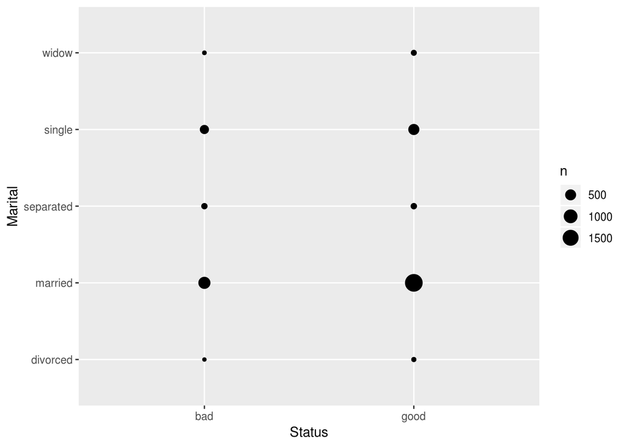

```r
ggplot() + geom_count(data = df, aes(x = Status, Marital))
```

```r
table(df$Status, df$Marital)
```

```
##
##        divorced married separated single widow
##   bad        12     682        55    268    13
##   good       19    1982        58    516    41
```

### Отчет. Часть 2 – с чем связана выплата кредита?

Перенесите наиболее интересные гипотезы и результаты в файл credit-template.Rmd

Итоговый отчет пришлите нам в виде гиста с помощью share_report.